# [0] General Summary: QI gPPS Analysis Report

CNPI AMR

Last compiled on Sunday 05 October, 2025

# 📊 Report Overview

This report presents a **summary analysis** of the Global PPS (gPPS) inpatient dataset using the **WHO AWaRe classification framework**.  
The focus is on **empirical antibiotic prescribing practices** in adults with **Seven different** **community-acquired infections (CAIs)** in addition to **surgical prophylaxis (SP)**, aligned with WHO’s AWaRe Quality Indicators (QIs).

**1- Clinical Sepsis of Unknown Origin** (Based on WHO AWaRe book)  
▸ **gPPS diagnostic code:** `SEPSIS`  
▸ **gPPS definition:** Sepsis of any origin (e.g., urosepsis, pulmonary sepsis, etc.), sepsis syndrome, or septic shock with no clear anatomic site, including candidemia with septic symptoms.

**2- Bacterial Meningitis** (Based on WHO AWaRe book)  
▸ **gPPS diagnostic code:** `CNS`  
▸ **gPPS definition:** Includes central nervous system infections.

**3- Community-acquired Pneumonia** (Based on WHO AWaRe book)  
▸ **gPPS diagnostic code:** `Pneu`  
▸ **gPPS definition:** Includes pneumonia and other lower respiratory tract infections (LRTIs).

**4- Intra-abdominal Infections** (Based on WHO AWaRe book)  
▸ **gPPS diagnostic code:** `IA`  
▸ **gPPS definition:** Includes hepatobiliary infections, intra-abdominal abscesses, and general abdominal sepsis.

**5- Upper Urinary Tract Infections** (Based on WHO AWaRe book)  
▸ **gPPS diagnostic code:** `Pye`  
▸ **gPPS definition:** Includes pyelonephritis and catheter-associated upper urinary tract infections.

**6- Skin/Soft Tissue Infections** (Based on WHO AWaRe book)  
▸ **gPPS diagnostic code:** `SST`  
▸ **gPPS definition:** Includes cellulitis, wound infections (including surgical site infections), deep soft tissue not involving bone (e.g., infected pressure ulcers, diabetic ulcers), and abscesses.

**7- Bone and Joint Infections** (Based on WHO AWaRe book)  
▸ **gPPS diagnostic code:** `BJ`  
▸ **gPPS definition:** Includes septic arthritis (including prosthetic joint infections) and osteomyelitis.

**8- Surgical Prophylaxis** (Based on WHO AWaRe book)  
▸ **gPPS diagnostic code:** `Proph` (including all surgical prophylaxis codes)  
▸ **gPPS indication:** `SP1, SP2, SP3`  
▸ **gPPS definition:** Antibiotics given before, during, or after surgical procedures.

## 💬 Additional Notes

- Each condition was mapped based on **clinical assumptions** that align WHO QIs with gPPS diagnostic coding.
- The **intravenous (IV) route** was identified using the gPPS "Route" code `P` (Parenteral), encompassing IV, intrathecal, and intraperitoneal administration.
  - While "P" is not exclusively IV, it is used here as a **proxy for IV administration** given its predominance in empirical treatment practices.
- This script, along with subsequent ones, implements the WHO AWaRe (Access, Watch, Reserve) antibiotic use QIs for managing the conditions mentioned above in **adult inpatients** with CAIs or SP.
- It uses standardised data from the gPPS, specifically extracted from the **Excel-based outputs** received from gPPS by participating hospitals.

Only **adult patients** on **empirical treatment** with **CAIs** or **SP** indications deemed eligible for this analysis.

# 🔎 Patients eligibility check Condition N of Eligible Patients Analysis Suitability Bone/Joint Infection 12 ✅ Meningitis 23 ✅ Intra-abdominal Infection 11 ✅ Respiratory Tract Infection 24 ✅ Surgical Prophylaxis 21 ✅ Upper Urinary Tract Infection 7 ⚠️ Undifferentiated Sepsis 48 ✅ Skin/Soft Tissue Infection 5 ⚠️ **💡 Note:** The script is designed to work best with **>10** eligible cases per diagnostic group. Groups with fewer patients will still run, but results may be limited in insights and interpretability. **💡 Important:** Groups with fewer than 10 patients are analysed with caution for interpretability. This section summrises the number of admitted and treated patients in different department across the hospital The total number of patients admitted in the hospital is **295**. **By Department type:** Department type: **Adult Intensive Care Units** has **124** patients. Department type: **General or mixed Adult Medical Ward** has **106** patients. Department type: **Orthopaedics-Trauma surg.** has **65** patients. **By Activity Type:** Activity Code: **M (Medical)** has **45** patients. Activity Code: **S (Surgical)** has **250** patients. The total number of treated patients in the hospital is **220**. **By Department type:** Department Type: **Adult Intensive Care Units** has **100** treated patients. Department Type: **General or mixed Adult Medical Ward** has **88** treated patients. Department Type: **Orthopaedics-Trauma surg.** has **32** treated patients. **By Activity Type:** Activity Code: **M (Medical)** has **34** treated patients. Activity Code: **S (Surgical)** has **186** treated patients. Metric Ward Total patients Patients for QIs-related groups Total Patients Given **Antimicrobials** Hospital-Wide 206 150 Total Patients Given **Antibiotics** Hospital-Wide 205 150 Patients Given **Access** Antibiotics Hospital-Wide 62 37 Patients Given **Watch** Antibiotics Hospital-Wide 124 97 Patients Given **Reserve** Antibiotics Hospital-Wide 18 16 Patients Given **Not Recommended** Antibiotics Hospital-Wide 5 3 Patients Given **Antibiotics** Adult Intensive Care Units 52 38 Patients Given **Access** Antibiotics Adult Intensive Care Units 12 8 Patients Given **Watch** Antibiotics Adult Intensive Care Units 35 26 Patients Given **Reserve** Antibiotics Adult Intensive Care Units 8 7 Patients Given **Antibiotics** Adult surgical wards 21 21 Patients Given **Access** Antibiotics Adult surgical wards 1 1 Patients Given **Watch** Antibiotics Adult surgical wards 17 17 Patients Given **Reserve** Antibiotics Adult surgical wards 3 3 Patients Given **Antibiotics** General Medical Ward 92 65 Patients Given **Access** Antibiotics General Medical Ward 35 17 Patients Given **Watch** Antibiotics General Medical Ward 48 40 Patients Given **Reserve** Antibiotics General Medical Ward 5 5 Patients Given **Not Recommended** Antibiotics General Medical Ward 5 3 Patients Given **Antibiotics** Haematology-Oncology 32 18 Patients Given **Access** Antibiotics Haematology-Oncology 7 5 Patients Given **Watch** Antibiotics Haematology-Oncology 22 12 Patients Given **Reserve** Antibiotics Haematology-Oncology 2 1 Patients Given **Antibiotics** Orthopedic ward 9 8 Patients Given **Access** Antibiotics Orthopedic ward 7 6 Patients Given **Watch** Antibiotics Orthopedic ward 2 2 Metric Ward Total prescriptions Prescriptions for QIs-related groups Total **Antimicrobial** Prescriptions Hospital-Wide 216 158 Total **Antibiotics** Prescriptions Hospital-Wide 215 158 **Access** Antibiotics Hospital-Wide 64 38 **Watch** Antibiotics Hospital-Wide 127 100 **Reserve** Antibiotics Hospital-Wide 18 16 **Not Recommended** Antibiotics Hospital-Wide 5 3 Total **Antibiotics** Prescriptions Adult Intensive Care Units 56 42 **Access** Antibiotics Adult Intensive Care Units 13 9 **Watch** Antibiotics Adult Intensive Care Units 35 26 **Reserve** Antibiotics Adult Intensive Care Units 8 7 Total **Antibiotics** Prescriptions Adult surgical wards 21 21 **Access** Antibiotics Adult surgical wards 1 1 **Watch** Antibiotics Adult surgical wards 17 17 **Reserve** Antibiotics Adult surgical wards 3 3 Total **Antibiotics** Prescriptions General Medical Ward 97 68 **Access** Antibiotics General Medical Ward 36 17 **Watch** Antibiotics General Medical Ward 50 42 **Reserve** Antibiotics General Medical Ward 5 5 **Not Recommended** Antibiotics General Medical Ward 5 3 Total **Antibiotics** Prescriptions Haematology-Oncology 33 19 **Access** Antibiotics Haematology-Oncology 7 5 **Watch** Antibiotics Haematology-Oncology 23 13 **Reserve** Antibiotics Haematology-Oncology 2 1 Total **Antibiotics** Prescriptions Orthopedic ward 9 8 **Access** Antibiotics Orthopedic ward 7 6 **Watch** Antibiotics Orthopedic ward 2 2 **💡 Note:** The AWaRe classification divides antibiotics into three categories: Access, Watch, and Reserve. Access antibiotics are first-line treatments with a low risk of resistance, typically recommended for common infections. Watch antibiotics are associated with a higher risk of resistance and require careful monitoring. Reserve antibiotics are reserved for critical cases involving resistant infections, typically used only when other options are ineffective . **💡 Note:** “Patients/Prescriptions for QI-related groups” refers specifically to patients or prescriptions involving **empiric antibiotics** for any of the **eight pre-defined conditions**. This plot provides a general summary of antibiotic prescriptions across pre-defined diagnostic groups, regardless of age, indication, or type of treatment This plot provides a general summary of patient-level antibiotic prescriptions for pre-defined diagnostic groups and across different departments, regardless of age, indication, or type of treatment **💡 Notes:** Counts patients prescribed at least one antimicrobial for each diagnosis. Patients may appear multiple times if they had multiple infections (same as the Global PPS standard). Patients can appear in multiple AWaRe categories if prescribed multiple types (e.g., both Access and Watch). This heatmap summarises the distribution across treatment types (empirical, targeted) and indications (CAI, HAI), separated by age groups. **💡 Note:** This analysis focuses on **adult patients** receiving **empiric antibiotic therapy** for **CAIs**. This section summarises prophylaxis indications (Surgical, Medical, Other, Unknown) across adult and pediatric patients. **💡 Note:** This analysis further includes **adult patients** receiving **empiric antibiotics** for the sole purpose of **surgical prophylaxis**, thereby excluding other prophylactics.

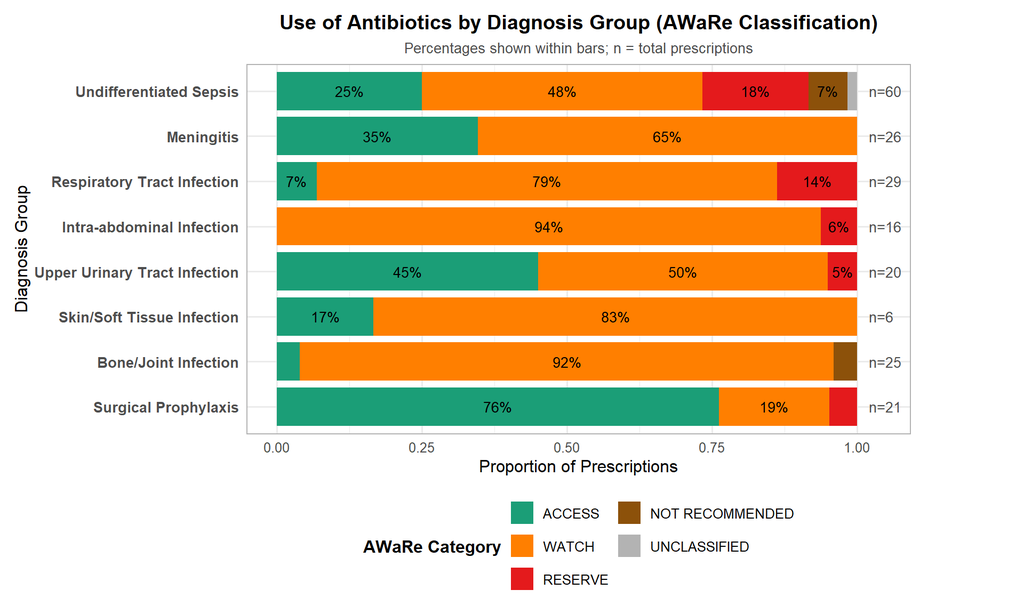

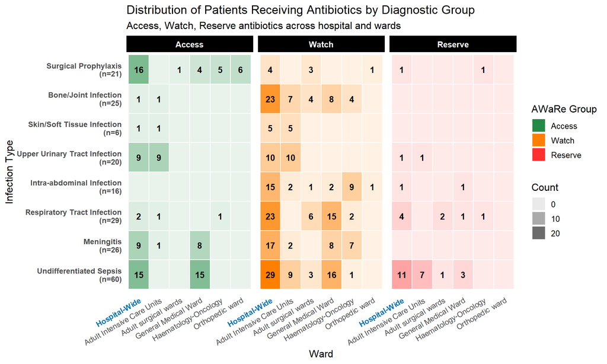

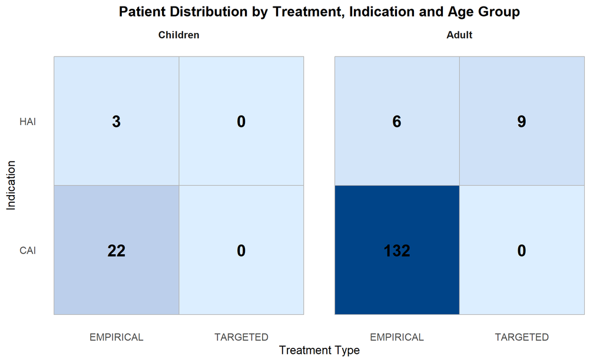

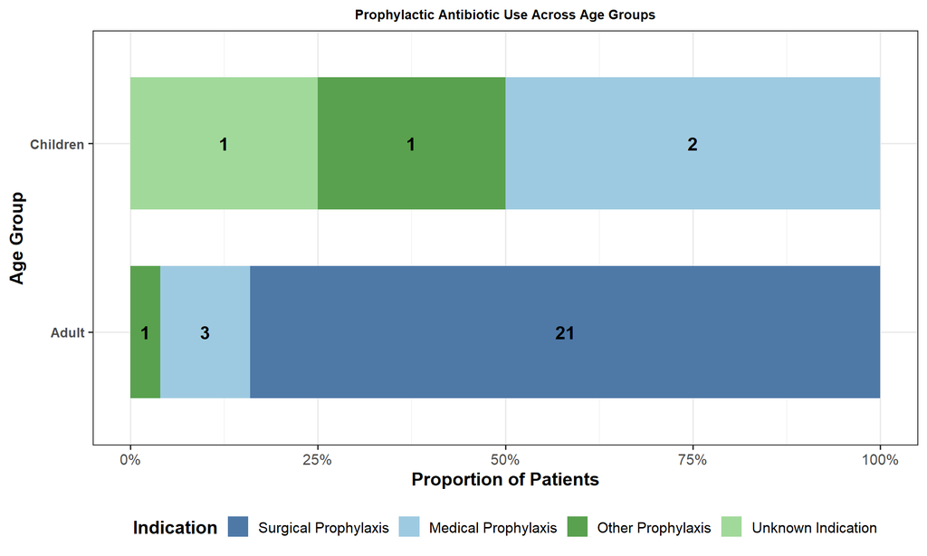